# Risk Factor Analysis

## Outcome Variable

**Outcome Variable:** haz

## Predictor Variables

**Intervention Variable:** parity

**Adjustment Set:**

unadjusted

## Stratifying Variables

The analysis was stratified on these variable(s):

- agecat
- studyid
- country

## Data Summary

| agecat | studyid | country | parity | n_cell | n |
| --- | --- | --- | --- | --- | --- |
| Birth | ki1000304b-SAS-CompFeed | INDIA | 1 | 47 | 187 |
| Birth | ki1000304b-SAS-CompFeed | INDIA | 2 | 53 | 187 |
| Birth | ki1000304b-SAS-CompFeed | INDIA | 3+ | 87 | 187 |
| Birth | ki1101329-Keneba | GAMBIA | 1 | 156 | 1407 |
| Birth | ki1101329-Keneba | GAMBIA | 2 | 146 | 1407 |
| Birth | ki1101329-Keneba | GAMBIA | 3+ | 1105 | 1407 |
| Birth | ki1126311-ZVITAMBO | ZIMBABWE | 1 | 5972 | 13829 |
| Birth | ki1126311-ZVITAMBO | ZIMBABWE | 2 | 4125 | 13829 |
| Birth | ki1126311-ZVITAMBO | ZIMBABWE | 3+ | 3732 | 13829 |
| Birth | ki1135781-COHORTS | GUATEMALA | 1 | 112 | 852 |
| Birth | ki1135781-COHORTS | GUATEMALA | 2 | 137 | 852 |
| Birth | ki1135781-COHORTS | GUATEMALA | 3+ | 603 | 852 |
| Birth | ki1135781-COHORTS | INDIA | 1 | 696 | 4122 |
| Birth | ki1135781-COHORTS | INDIA | 2 | 1037 | 4122 |
| Birth | ki1135781-COHORTS | INDIA | 3+ | 2389 | 4122 |
| Birth | ki1135781-COHORTS | PHILIPPINES | 1 | 675 | 3050 |
| Birth | ki1135781-COHORTS | PHILIPPINES | 2 | 687 | 3050 |
| Birth | ki1135781-COHORTS | PHILIPPINES | 3+ | 1688 | 3050 |
| Birth | kiGH5241-JiVitA-3 | BANGLADESH | 1 | 6271 | 19594 |
| Birth | kiGH5241-JiVitA-3 | BANGLADESH | 2 | 6710 | 19594 |
| Birth | kiGH5241-JiVitA-3 | BANGLADESH | 3+ | 6613 | 19594 |
| 6 months | ki1000304b-SAS-CompFeed | INDIA | 1 | 392 | 1336 |
| 6 months | ki1000304b-SAS-CompFeed | INDIA | 2 | 304 | 1336 |
| 6 months | ki1000304b-SAS-CompFeed | INDIA | 3+ | 640 | 1336 |
| 6 months | ki1000304b-SAS-FoodSuppl | INDIA | 1 | 72 | 373 |
| 6 months | ki1000304b-SAS-FoodSuppl | INDIA | 2 | 84 | 373 |
| 6 months | ki1000304b-SAS-FoodSuppl | INDIA | 3+ | 217 | 373 |
| 6 months | ki1017093b-PROVIDE | BANGLADESH | 1 | 211 | 583 |
| 6 months | ki1017093b-PROVIDE | BANGLADESH | 2 | 212 | 583 |
| 6 months | ki1017093b-PROVIDE | BANGLADESH | 3+ | 160 | 583 |

[output cut: 51 more lines]

The following strata were considered:

- agecat: 24 months, studyid: ki1017093b-PROVIDE, country: BANGLADESH
- agecat: 24 months, studyid: ki1066203-TanzaniaChild2, country: TANZANIA, UNITED REPUBLIC OF
- agecat: 24 months, studyid: ki1101329-Keneba, country: GAMBIA
- agecat: 24 months, studyid: ki1113344-GMS-Nepal, country: NEPAL
- agecat: 24 months, studyid: ki1126311-ZVITAMBO, country: ZIMBABWE
- agecat: 24 months, studyid: ki1135781-COHORTS, country: GUATEMALA
- agecat: 24 months, studyid: ki1135781-COHORTS, country: INDIA
- agecat: 24 months, studyid: ki1135781-COHORTS, country: PHILIPPINES
- agecat: 24 months, studyid: kiGH5241-JiVitA-3, country: BANGLADESH
- agecat: 6 months, studyid: ki1000304b-SAS-CompFeed, country: INDIA
- agecat: 6 months, studyid: ki1000304b-SAS-FoodSuppl, country: INDIA
- agecat: 6 months, studyid: ki1017093b-PROVIDE, country: BANGLADESH
- agecat: 6 months, studyid: ki1066203-TanzaniaChild2, country: TANZANIA, UNITED REPUBLIC OF
- agecat: 6 months, studyid: ki1101329-Keneba, country: GAMBIA
- agecat: 6 months, studyid: ki1113344-GMS-Nepal, country: NEPAL
- agecat: 6 months, studyid: ki1126311-ZVITAMBO, country: ZIMBABWE
- agecat: 6 months, studyid: ki1135781-COHORTS, country: GUATEMALA
- agecat: 6 months, studyid: ki1135781-COHORTS, country: INDIA
- agecat: 6 months, studyid: ki1135781-COHORTS, country: PHILIPPINES
- agecat: 6 months, studyid: kiGH5241-JiVitA-3, country: BANGLADESH
- agecat: Birth, studyid: ki1000304b-SAS-CompFeed, country: INDIA
- agecat: Birth, studyid: ki1101329-Keneba, country: GAMBIA
- agecat: Birth, studyid: ki1126311-ZVITAMBO, country: ZIMBABWE
- agecat: Birth, studyid: ki1135781-COHORTS, country: GUATEMALA
- agecat: Birth, studyid: ki1135781-COHORTS, country: INDIA
- agecat: Birth, studyid: ki1135781-COHORTS, country: PHILIPPINES
- agecat: Birth, studyid: kiGH5241-JiVitA-3, country: BANGLADESH

### Dropped Strata

Some strata were dropped due to rare outcomes:

- agecat: 24 months, studyid: ki1066203-TanzaniaChild2, country: TANZANIA, UNITED REPUBLIC OF

## Methods Detail

We’re interested in the causal parameters $E[Y_a]$ for all values of $a \in \mathcal{A}$. These parameters represent the mean outcome if, possibly contrary to fact, we intervened to set all units to have $A=a$. Under the randomization and positivity assumptions, these are identified by the statistical parameters $\psi_a=E_W[E_{Y|A,W}(Y|A=a,W)]$. In addition, we’re interested in the mean of $Y$, $E[Y]$ under no intervention (the observed mean). We will estimate these parameters by using SuperLearner to fit the relevant likelihood factors – $E_{Y|A,W}(Y|A=a,W)$ and $p(A=a|W)$, and then updating our likelihood fit using a joint TMLE.

For unadjusted analyses ($W=\{\}$), initial likelihoods were estimated using Lrnr_glm to estimate the simple $E(Y|A)$ and Lrnr_mean to estimate $p(A)$. For adjusted analyses, a small library containing Lrnr_glmnet, Lrnr_xgboost, and Lrnr_mean was used.

Having estimated these parameters, we will then use the delta method to estimate relative risks and attributable risks relative to a prespecified baseline level of $A$.

# Results Detail

## Results Plots

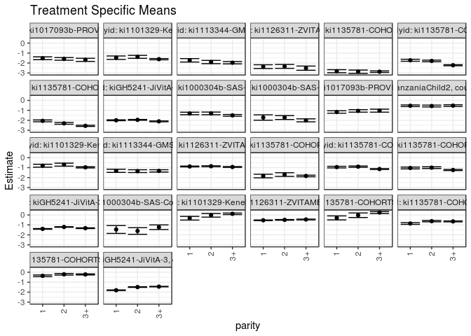

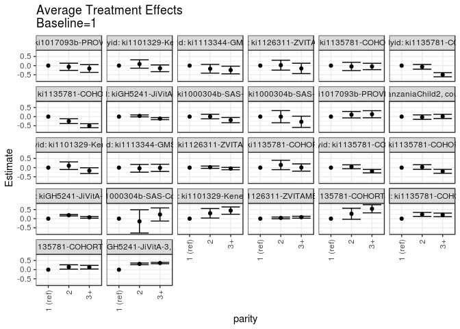

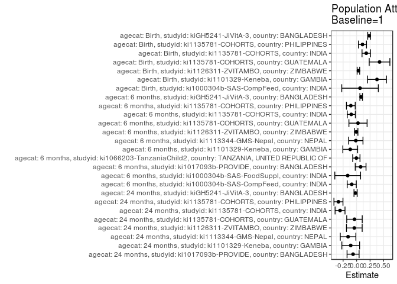

## Results Table

### Parameter: TSM

| agecat | studyid | country | intervention_level | baseline_level | estimate | ci_lower | ci_upper |
| --- | --- | --- | --- | --- | --- | --- | --- |
| Birth | ki1000304b-SAS-CompFeed | INDIA | 1 | NA | -1.4585106 | -1.8541897 | -1.0628316 |
| Birth | ki1000304b-SAS-CompFeed | INDIA | 2 | NA | -1.6077358 | -1.9401615 | -1.2753102 |
| Birth | ki1000304b-SAS-CompFeed | INDIA | 3+ | NA | -1.2303448 | -1.4631389 | -0.9975507 |
| Birth | ki1101329-Keneba | GAMBIA | 1 | NA | -0.3278846 | -0.5117293 | -0.1440399 |
| Birth | ki1101329-Keneba | GAMBIA | 2 | NA | -0.0329452 | -0.2164585 | 0.1505681 |
| Birth | ki1101329-Keneba | GAMBIA | 3+ | NA | 0.1137919 | 0.0374859 | 0.1900979 |
| Birth | ki1126311-ZVITAMBO | ZIMBABWE | 1 | NA | -0.5347338 | -0.5662204 | -0.5032471 |
| Birth | ki1126311-ZVITAMBO | ZIMBABWE | 2 | NA | -0.4934909 | -0.5295287 | -0.4574531 |
| Birth | ki1126311-ZVITAMBO | ZIMBABWE | 3+ | NA | -0.4553778 | -0.4964009 | -0.4143547 |
| Birth | ki1135781-COHORTS | GUATEMALA | 1 | NA | -0.2955357 | -0.4961176 | -0.0949538 |
| Birth | ki1135781-COHORTS | GUATEMALA | 2 | NA | -0.0281752 | -0.2562105 | 0.1998601 |
| Birth | ki1135781-COHORTS | GUATEMALA | 3+ | NA | 0.2445937 | 0.1463298 | 0.3428576 |
| Birth | ki1135781-COHORTS | INDIA | 1 | NA | -0.8560489 | -0.9418893 | -0.7702084 |
| Birth | ki1135781-COHORTS | INDIA | 2 | NA | -0.6238284 | -0.6910831 | -0.5565736 |
| Birth | ki1135781-COHORTS | INDIA | 3+ | NA | -0.6484763 | -0.6951610 | -0.6017917 |
| Birth | ki1135781-COHORTS | PHILIPPINES | 1 | NA | -0.3580296 | -0.4429059 | -0.2731534 |
| Birth | ki1135781-COHORTS | PHILIPPINES | 2 | NA | -0.2091994 | -0.2907964 | -0.1276025 |
| Birth | ki1135781-COHORTS | PHILIPPINES | 3+ | NA | -0.2216884 | -0.2736422 | -0.1697346 |
| Birth | kiGH5241-JiVitA-3 | BANGLADESH | 1 | NA | -1.8066592 | -1.8385884 | -1.7747300 |
| Birth | kiGH5241-JiVitA-3 | BANGLADESH | 2 | NA | -1.4891624 | -1.5213900 | -1.4569349 |
| Birth | kiGH5241-JiVitA-3 | BANGLADESH | 3+ | NA | -1.4423741 | -1.4707280 | -1.4140203 |
| 6 months | ki1000304b-SAS-CompFeed | INDIA | 1 | NA | -1.3118367 | -1.4373576 | -1.1863158 |
| 6 months | ki1000304b-SAS-CompFeed | INDIA | 2 | NA | -1.3070888 | -1.4410886 | -1.1730890 |
| 6 months | ki1000304b-SAS-CompFeed | INDIA | 3+ | NA | -1.5020078 | -1.5877472 | -1.4162684 |
| 6 months | ki1000304b-SAS-FoodSuppl | INDIA | 1 | NA | -1.7179167 | -1.9871700 | -1.4486633 |
| 6 months | ki1000304b-SAS-FoodSuppl | INDIA | 2 | NA | -1.7209524 | -1.9164103 | -1.5254944 |
| 6 months | ki1000304b-SAS-FoodSuppl | INDIA | 3+ | NA | -2.0004147 | -2.1496420 | -1.8511875 |
| 6 months | ki1017093b-PROVIDE | BANGLADESH | 1 | NA | -1.1618088 | -1.2838757 | -1.0397420 |
| 6 months | ki1017093b-PROVIDE | BANGLADESH | 2 | NA | -1.0549764 | -1.1824321 | -0.9275208 |
| 6 months | ki1017093b-PROVIDE | BANGLADESH | 3+ | NA | -1.0311562 | -1.1824160 | -0.8798965 |
| 6 months | ki1066203-TanzaniaChild2 | TANZANIA, UNITED REPUBLIC OF | 1 | NA | -0.5386838 | -0.6201834 | -0.4571842 |
| 6 months | ki1066203-TanzaniaChild2 | TANZANIA, UNITED REPUBLIC OF | 2 | NA | -0.5657902 | -0.6562982 | -0.4752822 |
| 6 months | ki1066203-TanzaniaChild2 | TANZANIA, UNITED REPUBLIC OF | 3+ | NA | -0.5255471 | -0.6099074 | -0.4411868 |
| 6 months | ki1101329-Keneba | GAMBIA | 1 | NA | -0.8062506 | -0.9513604 | -0.6611408 |
| 6 months | ki1101329-Keneba | GAMBIA | 2 | NA | -0.6999654 | -0.8511450 | -0.5487859 |
| 6 months | ki1101329-Keneba | GAMBIA | 3+ | NA | -0.9710240 | -1.0317692 | -0.9102787 |
| 6 months | ki1113344-GMS-Nepal | NEPAL | 1 | NA | -1.3173747 | -1.4765615 | -1.1581880 |
| 6 months | ki1113344-GMS-Nepal | NEPAL | 2 | NA | -1.3532998 | -1.4941009 | -1.2124987 |
| 6 months | ki1113344-GMS-Nepal | NEPAL | 3+ | NA | -1.3287420 | -1.4440326 | -1.2134514 |
| 6 months | ki1126311-ZVITAMBO | ZIMBABWE | 1 | NA | -0.8830103 | -0.9244545 | -0.8415661 |
| 6 months | ki1126311-ZVITAMBO | ZIMBABWE | 2 | NA | -0.8593953 | -0.9054914 | -0.8132992 |
| 6 months | ki1126311-ZVITAMBO | ZIMBABWE | 3+ | NA | -0.9332672 | -0.9814029 | -0.8851315 |
| 6 months | ki1135781-COHORTS | GUATEMALA | 1 | NA | -1.8418939 | -2.0228076 | -1.6609802 |
| 6 months | ki1135781-COHORTS | GUATEMALA | 2 | NA | -1.6951799 | -1.8774684 | -1.5128913 |
| 6 months | ki1135781-COHORTS | GUATEMALA | 3+ | NA | -1.8350145 | -1.9150976 | -1.7549314 |
| 6 months | ki1135781-COHORTS | INDIA | 1 | NA | -0.9470541 | -1.0297223 | -0.8643858 |
| 6 months | ki1135781-COHORTS | INDIA | 2 | NA | -0.8993339 | -0.9666636 | -0.8320043 |
| 6 months | ki1135781-COHORTS | INDIA | 3+ | NA | -1.1404318 | -1.1872366 | -1.0936270 |
| 6 months | ki1135781-COHORTS | PHILIPPINES | 1 | NA | -1.0339895 | -1.1258821 | -0.9420970 |
| 6 months | ki1135781-COHORTS | PHILIPPINES | 2 | NA | -1.0007261 | -1.0872914 | -0.9141607 |
| 6 months | ki1135781-COHORTS | PHILIPPINES | 3+ | NA | -1.2360733 | -1.2917219 | -1.1804247 |
| 6 months | kiGH5241-JiVitA-3 | BANGLADESH | 1 | NA | -1.3976378 | -1.4314066 | -1.3638689 |
| 6 months | kiGH5241-JiVitA-3 | BANGLADESH | 2 | NA | -1.2072930 | -1.2384526 | -1.1761333 |
| 6 months | kiGH5241-JiVitA-3 | BANGLADESH | 3+ | NA | -1.3268653 | -1.3640511 | -1.2896796 |
| 24 months | ki1017093b-PROVIDE | BANGLADESH | 1 | NA | -1.5208531 | -1.6642827 | -1.3774235 |
| 24 months | ki1017093b-PROVIDE | BANGLADESH | 2 | NA | -1.5848357 | -1.7186723 | -1.4509991 |
| 24 months | ki1017093b-PROVIDE | BANGLADESH | 3+ | NA | -1.6779085 | -1.8340014 | -1.5218156 |
| 24 months | ki1101329-Keneba | GAMBIA | 1 | NA | -1.4648017 | -1.6375143 | -1.2920891 |
| 24 months | ki1101329-Keneba | GAMBIA | 2 | NA | -1.3779556 | -1.5281633 | -1.2277480 |
| 24 months | ki1101329-Keneba | GAMBIA | 3+ | NA | -1.6116744 | -1.6755419 | -1.5478069 |
| 24 months | ki1113344-GMS-Nepal | NEPAL | 1 | NA | -1.7255515 | -1.8989056 | -1.5521973 |
| 24 months | ki1113344-GMS-Nepal | NEPAL | 2 | NA | -1.8985385 | -2.0618372 | -1.7352397 |
| 24 months | ki1113344-GMS-Nepal | NEPAL | 3+ | NA | -1.9674964 | -2.0853799 | -1.8496129 |
| 24 months | ki1126311-ZVITAMBO | ZIMBABWE | 1 | NA | -2.3604520 | -2.5486016 | -2.1723024 |
| 24 months | ki1126311-ZVITAMBO | ZIMBABWE | 2 | NA | -2.3375373 | -2.5327844 | -2.1422902 |
| 24 months | ki1126311-ZVITAMBO | ZIMBABWE | 3+ | NA | -2.5142069 | -2.7267670 | -2.3016468 |
| 24 months | ki1135781-COHORTS | GUATEMALA | 1 | NA | -2.8205389 | -2.9754533 | -2.6656245 |
| 24 months | ki1135781-COHORTS | GUATEMALA | 2 | NA | -2.8675497 | -3.0314134 | -2.7036859 |
| 24 months | ki1135781-COHORTS | GUATEMALA | 3+ | NA | -2.8669025 | -2.9451903 | -2.7886148 |
| 24 months | ki1135781-COHORTS | INDIA | 1 | NA | -1.7211150 | -1.8215657 | -1.6206644 |
| 24 months | ki1135781-COHORTS | INDIA | 2 | NA | -1.7875059 | -1.8682524 | -1.7067594 |
| 24 months | ki1135781-COHORTS | INDIA | 3+ | NA | -2.2195884 | -2.2725608 | -2.1666160 |
| 24 months | ki1135781-COHORTS | PHILIPPINES | 1 | NA | -2.0537214 | -2.1469638 | -1.9604789 |
| 24 months | ki1135781-COHORTS | PHILIPPINES | 2 | NA | -2.3031618 | -2.3954576 | -2.2108660 |
| 24 months | ki1135781-COHORTS | PHILIPPINES | 3+ | NA | -2.5520334 | -2.6115668 | -2.4925000 |
| 24 months | kiGH5241-JiVitA-3 | BANGLADESH | 1 | NA | -1.9938452 | -2.0355447 | -1.9521456 |
| 24 months | kiGH5241-JiVitA-3 | BANGLADESH | 2 | NA | -1.9537667 | -1.9940089 | -1.9135245 |
| 24 months | kiGH5241-JiVitA-3 | BANGLADESH | 3+ | NA | -2.1039314 | -2.1471384 | -2.0607244 |

### Parameter: E(Y)

| agecat | studyid | country | intervention_level | baseline_level | estimate | ci_lower | ci_upper |
| --- | --- | --- | --- | --- | --- | --- | --- |
| Birth | ki1000304b-SAS-CompFeed | INDIA | NA | NA | -1.3946524 | -1.5833612 | -1.2059436 |
| Birth | ki1101329-Keneba | GAMBIA | NA | NA | 0.0495949 | -0.0169135 | 0.1161033 |
| Birth | ki1126311-ZVITAMBO | ZIMBABWE | NA | NA | -0.5010160 | -0.5215903 | -0.4804417 |
| Birth | ki1135781-COHORTS | GUATEMALA | NA | NA | 0.1297300 | 0.0458017 | 0.2136584 |
| Birth | ki1135781-COHORTS | INDIA | NA | NA | -0.6773241 | -0.7124609 | -0.6421873 |
| Birth | ki1135781-COHORTS | PHILIPPINES | NA | NA | -0.2490492 | -0.2880580 | -0.2100404 |
| Birth | kiGH5241-JiVitA-3 | BANGLADESH | NA | NA | -1.5749852 | -1.5947616 | -1.5552088 |
| 6 months | ki1000304b-SAS-CompFeed | INDIA | NA | NA | -1.4018563 | -1.4810585 | -1.3226541 |
| 6 months | ki1000304b-SAS-FoodSuppl | INDIA | NA | NA | -1.8829491 | -1.9941876 | -1.7717105 |
| 6 months | ki1017093b-PROVIDE | BANGLADESH | NA | NA | -1.0871041 | -1.1635539 | -1.0106543 |
| 6 months | ki1066203-TanzaniaChild2 | TANZANIA, UNITED REPUBLIC OF | NA | NA | -0.5432778 | -0.5926218 | -0.4939338 |
| 6 months | ki1101329-Keneba | GAMBIA | NA | NA | -0.9239386 | -0.9768148 | -0.8710623 |
| 6 months | ki1113344-GMS-Nepal | NEPAL | NA | NA | -1.3321522 | -1.4103691 | -1.2539352 |
| 6 months | ki1126311-ZVITAMBO | ZIMBABWE | NA | NA | -0.8907964 | -0.9167695 | -0.8648233 |
| 6 months | ki1135781-COHORTS | GUATEMALA | NA | NA | -1.8157336 | -1.8837688 | -1.7476985 |
| 6 months | ki1135781-COHORTS | INDIA | NA | NA | -1.0455022 | -1.0805318 | -1.0104727 |
| 6 months | ki1135781-COHORTS | PHILIPPINES | NA | NA | -1.1405724 | -1.1824954 | -1.0986493 |
| 6 months | kiGH5241-JiVitA-3 | BANGLADESH | NA | NA | -1.3132090 | -1.3363486 | -1.2900693 |
| 24 months | ki1017093b-PROVIDE | BANGLADESH | NA | NA | -1.5861179 | -1.6693668 | -1.5028689 |
| 24 months | ki1101329-Keneba | GAMBIA | NA | NA | -1.5734415 | -1.6295670 | -1.5173160 |
| 24 months | ki1113344-GMS-Nepal | NEPAL | NA | NA | -1.8835905 | -1.9681499 | -1.7990312 |
| 24 months | ki1126311-ZVITAMBO | ZIMBABWE | NA | NA | -2.4026096 | -2.5176913 | -2.2875280 |
| 24 months | ki1135781-COHORTS | GUATEMALA | NA | NA | -2.8597376 | -2.9241330 | -2.7953421 |
| 24 months | ki1135781-COHORTS | INDIA | NA | NA | -2.0277742 | -2.0690209 | -1.9865275 |
| 24 months | ki1135781-COHORTS | PHILIPPINES | NA | NA | -2.3898650 | -2.4346888 | -2.3450412 |
| 24 months | kiGH5241-JiVitA-3 | BANGLADESH | NA | NA | -2.0126333 | -2.0403442 | -1.9849225 |

### Parameter: ATE

| agecat | studyid | country | intervention_level | baseline_level | estimate | ci_lower | ci_upper |
| --- | --- | --- | --- | --- | --- | --- | --- |
| Birth | ki1000304b-SAS-CompFeed | INDIA | 1 | 1 | 0.0000000 | 0.0000000 | 0.0000000 |
| Birth | ki1000304b-SAS-CompFeed | INDIA | 2 | 1 | -0.1492252 | -0.7860765 | 0.4876261 |
| Birth | ki1000304b-SAS-CompFeed | INDIA | 3+ | 1 | 0.2281658 | -0.1300640 | 0.5863956 |
| Birth | ki1101329-Keneba | GAMBIA | 1 | 1 | 0.0000000 | 0.0000000 | 0.0000000 |
| Birth | ki1101329-Keneba | GAMBIA | 2 | 1 | 0.2949394 | 0.0351780 | 0.5547009 |
| Birth | ki1101329-Keneba | GAMBIA | 3+ | 1 | 0.4416765 | 0.2426250 | 0.6407279 |
| Birth | ki1126311-ZVITAMBO | ZIMBABWE | 1 | 1 | 0.0000000 | 0.0000000 | 0.0000000 |
| Birth | ki1126311-ZVITAMBO | ZIMBABWE | 2 | 1 | 0.0412428 | -0.0066125 | 0.0890982 |
| Birth | ki1126311-ZVITAMBO | ZIMBABWE | 3+ | 1 | 0.0793559 | 0.0276423 | 0.1310696 |
| Birth | ki1135781-COHORTS | GUATEMALA | 1 | 1 | 0.0000000 | 0.0000000 | 0.0000000 |
| Birth | ki1135781-COHORTS | GUATEMALA | 2 | 1 | 0.2673605 | -0.0363386 | 0.5710597 |
| Birth | ki1135781-COHORTS | GUATEMALA | 3+ | 1 | 0.5401294 | 0.3167712 | 0.7634876 |
| Birth | ki1135781-COHORTS | INDIA | 1 | 1 | 0.0000000 | 0.0000000 | 0.0000000 |
| Birth | ki1135781-COHORTS | INDIA | 2 | 1 | 0.2322205 | 0.1231711 | 0.3412699 |
| Birth | ki1135781-COHORTS | INDIA | 3+ | 1 | 0.2075725 | 0.1098585 | 0.3052865 |
| Birth | ki1135781-COHORTS | PHILIPPINES | 1 | 1 | 0.0000000 | 0.0000000 | 0.0000000 |
| Birth | ki1135781-COHORTS | PHILIPPINES | 2 | 1 | 0.1488302 | 0.0310930 | 0.2665674 |
| Birth | ki1135781-COHORTS | PHILIPPINES | 3+ | 1 | 0.1363412 | 0.0368266 | 0.2358559 |
| Birth | kiGH5241-JiVitA-3 | BANGLADESH | 1 | 1 | 0.0000000 | 0.0000000 | 0.0000000 |
| Birth | kiGH5241-JiVitA-3 | BANGLADESH | 2 | 1 | 0.3174968 | 0.2725455 | 0.3624480 |
| Birth | kiGH5241-JiVitA-3 | BANGLADESH | 3+ | 1 | 0.3642851 | 0.3249024 | 0.4036678 |
| 6 months | ki1000304b-SAS-CompFeed | INDIA | 1 | 1 | 0.0000000 | 0.0000000 | 0.0000000 |
| 6 months | ki1000304b-SAS-CompFeed | INDIA | 2 | 1 | 0.0047479 | -0.1210126 | 0.1305084 |
| 6 months | ki1000304b-SAS-CompFeed | INDIA | 3+ | 1 | -0.1901711 | -0.3323896 | -0.0479526 |
| 6 months | ki1000304b-SAS-FoodSuppl | INDIA | 1 | 1 | 0.0000000 | 0.0000000 | 0.0000000 |
| 6 months | ki1000304b-SAS-FoodSuppl | INDIA | 2 | 1 | -0.0030357 | -0.3357536 | 0.3296822 |
| 6 months | ki1000304b-SAS-FoodSuppl | INDIA | 3+ | 1 | -0.2824981 | -0.5903392 | 0.0253430 |
| 6 months | ki1017093b-PROVIDE | BANGLADESH | 1 | 1 | 0.0000000 | 0.0000000 | 0.0000000 |
| 6 months | ki1017093b-PROVIDE | BANGLADESH | 2 | 1 | 0.1068324 | -0.0696477 | 0.2833126 |
| 6 months | ki1017093b-PROVIDE | BANGLADESH | 3+ | 1 | 0.1306526 | -0.0637178 | 0.3250229 |
| 6 months | ki1066203-TanzaniaChild2 | TANZANIA, UNITED REPUBLIC OF | 1 | 1 | 0.0000000 | 0.0000000 | 0.0000000 |
| 6 months | ki1066203-TanzaniaChild2 | TANZANIA, UNITED REPUBLIC OF | 2 | 1 | -0.0271064 | -0.1489009 | 0.0946881 |
| 6 months | ki1066203-TanzaniaChild2 | TANZANIA, UNITED REPUBLIC OF | 3+ | 1 | 0.0131367 | -0.1041614 | 0.1304348 |
| 6 months | ki1101329-Keneba | GAMBIA | 1 | 1 | 0.0000000 | 0.0000000 | 0.0000000 |
| 6 months | ki1101329-Keneba | GAMBIA | 2 | 1 | 0.1062851 | -0.1032670 | 0.3158373 |
| 6 months | ki1101329-Keneba | GAMBIA | 3+ | 1 | -0.1647734 | -0.3220847 | -0.0074621 |
| 6 months | ki1113344-GMS-Nepal | NEPAL | 1 | 1 | 0.0000000 | 0.0000000 | 0.0000000 |
| 6 months | ki1113344-GMS-Nepal | NEPAL | 2 | 1 | -0.0359250 | -0.2484465 | 0.1765964 |
| 6 months | ki1113344-GMS-Nepal | NEPAL | 3+ | 1 | -0.0113673 | -0.2079184 | 0.1851838 |
| 6 months | ki1126311-ZVITAMBO | ZIMBABWE | 1 | 1 | 0.0000000 | 0.0000000 | 0.0000000 |
| 6 months | ki1126311-ZVITAMBO | ZIMBABWE | 2 | 1 | 0.0236150 | -0.0383727 | 0.0856026 |
| 6 months | ki1126311-ZVITAMBO | ZIMBABWE | 3+ | 1 | -0.0502569 | -0.1137760 | 0.0132621 |
| 6 months | ki1135781-COHORTS | GUATEMALA | 1 | 1 | 0.0000000 | 0.0000000 | 0.0000000 |
| 6 months | ki1135781-COHORTS | GUATEMALA | 2 | 1 | 0.1467141 | -0.1101105 | 0.4035387 |
| 6 months | ki1135781-COHORTS | GUATEMALA | 3+ | 1 | 0.0068794 | -0.1909666 | 0.2047255 |
| 6 months | ki1135781-COHORTS | INDIA | 1 | 1 | 0.0000000 | 0.0000000 | 0.0000000 |
| 6 months | ki1135781-COHORTS | INDIA | 2 | 1 | 0.0477201 | -0.0588975 | 0.1543378 |
| 6 months | ki1135781-COHORTS | INDIA | 3+ | 1 | -0.1933777 | -0.2883763 | -0.0983791 |
| 6 months | ki1135781-COHORTS | PHILIPPINES | 1 | 1 | 0.0000000 | 0.0000000 | 0.0000000 |
| 6 months | ki1135781-COHORTS | PHILIPPINES | 2 | 1 | 0.0332635 | -0.0929815 | 0.1595085 |
| 6 months | ki1135781-COHORTS | PHILIPPINES | 3+ | 1 | -0.2020838 | -0.3095128 | -0.0946547 |
| 6 months | kiGH5241-JiVitA-3 | BANGLADESH | 1 | 1 | 0.0000000 | 0.0000000 | 0.0000000 |
| 6 months | kiGH5241-JiVitA-3 | BANGLADESH | 2 | 1 | 0.1903448 | 0.1501180 | 0.2305715 |
| 6 months | kiGH5241-JiVitA-3 | BANGLADESH | 3+ | 1 | 0.0707724 | 0.0239924 | 0.1175524 |
| 24 months | ki1017093b-PROVIDE | BANGLADESH | 1 | 1 | 0.0000000 | 0.0000000 | 0.0000000 |
| 24 months | ki1017093b-PROVIDE | BANGLADESH | 2 | 1 | -0.0639826 | -0.2601567 | 0.1321915 |
| 24 months | ki1017093b-PROVIDE | BANGLADESH | 3+ | 1 | -0.1570554 | -0.3690390 | 0.0549282 |
| 24 months | ki1101329-Keneba | GAMBIA | 1 | 1 | 0.0000000 | 0.0000000 | 0.0000000 |
| 24 months | ki1101329-Keneba | GAMBIA | 2 | 1 | 0.0868461 | -0.1420468 | 0.3157390 |
| 24 months | ki1101329-Keneba | GAMBIA | 3+ | 1 | -0.1468727 | -0.3310158 | 0.0372704 |
| 24 months | ki1113344-GMS-Nepal | NEPAL | 1 | 1 | 0.0000000 | 0.0000000 | 0.0000000 |
| 24 months | ki1113344-GMS-Nepal | NEPAL | 2 | 1 | -0.1729870 | -0.4111427 | 0.0651687 |
| 24 months | ki1113344-GMS-Nepal | NEPAL | 3+ | 1 | -0.2419450 | -0.4515832 | -0.0323067 |
| 24 months | ki1126311-ZVITAMBO | ZIMBABWE | 1 | 1 | 0.0000000 | 0.0000000 | 0.0000000 |
| 24 months | ki1126311-ZVITAMBO | ZIMBABWE | 2 | 1 | 0.0229147 | -0.2482342 | 0.2940635 |
| 24 months | ki1126311-ZVITAMBO | ZIMBABWE | 3+ | 1 | -0.1537549 | -0.4376247 | 0.1301149 |
| 24 months | ki1135781-COHORTS | GUATEMALA | 1 | 1 | 0.0000000 | 0.0000000 | 0.0000000 |
| 24 months | ki1135781-COHORTS | GUATEMALA | 2 | 1 | -0.0470107 | -0.2725097 | 0.1784882 |
| 24 months | ki1135781-COHORTS | GUATEMALA | 3+ | 1 | -0.0463636 | -0.2199362 | 0.1272090 |
| 24 months | ki1135781-COHORTS | INDIA | 1 | 1 | 0.0000000 | 0.0000000 | 0.0000000 |
| 24 months | ki1135781-COHORTS | INDIA | 2 | 1 | -0.0663908 | -0.1952719 | 0.0624902 |
| 24 months | ki1135781-COHORTS | INDIA | 3+ | 1 | -0.4984734 | -0.6120357 | -0.3849110 |
| 24 months | ki1135781-COHORTS | PHILIPPINES | 1 | 1 | 0.0000000 | 0.0000000 | 0.0000000 |
| 24 months | ki1135781-COHORTS | PHILIPPINES | 2 | 1 | -0.2494404 | -0.3806375 | -0.1182433 |
| 24 months | ki1135781-COHORTS | PHILIPPINES | 3+ | 1 | -0.4983120 | -0.6089393 | -0.3876848 |
| 24 months | kiGH5241-JiVitA-3 | BANGLADESH | 1 | 1 | 0.0000000 | 0.0000000 | 0.0000000 |
| 24 months | kiGH5241-JiVitA-3 | BANGLADESH | 2 | 1 | 0.0400785 | -0.0121752 | 0.0923322 |
| 24 months | kiGH5241-JiVitA-3 | BANGLADESH | 3+ | 1 | -0.1100862 | -0.1660588 | -0.0541137 |

### Parameter: PAR

| agecat | studyid | country | intervention_level | baseline_level | estimate | ci_lower | ci_upper |
| --- | --- | --- | --- | --- | --- | --- | --- |
| Birth | ki1000304b-SAS-CompFeed | INDIA | 1 | NA | 0.0638582 | -0.2748841 | 0.4026005 |
| Birth | ki1101329-Keneba | GAMBIA | 1 | NA | 0.3774795 | 0.2021872 | 0.5527718 |
| Birth | ki1126311-ZVITAMBO | ZIMBABWE | 1 | NA | 0.0337178 | 0.0100865 | 0.0573491 |
| Birth | ki1135781-COHORTS | GUATEMALA | 1 | NA | 0.4252658 | 0.2336950 | 0.6168365 |
| Birth | ki1135781-COHORTS | INDIA | 1 | NA | 0.1787247 | 0.1005275 | 0.2569219 |
| Birth | ki1135781-COHORTS | PHILIPPINES | 1 | NA | 0.1089804 | 0.0345693 | 0.1833916 |
| Birth | kiGH5241-JiVitA-3 | BANGLADESH | 1 | NA | 0.2316740 | 0.2061563 | 0.2571917 |
| 6 months | ki1000304b-SAS-CompFeed | INDIA | 1 | NA | -0.0900196 | -0.1744402 | -0.0055989 |
| 6 months | ki1000304b-SAS-FoodSuppl | INDIA | 1 | NA | -0.1650324 | -0.4035342 | 0.0734694 |
| 6 months | ki1017093b-PROVIDE | BANGLADESH | 1 | NA | 0.0747048 | -0.0250920 | 0.1745016 |
| 6 months | ki1066203-TanzaniaChild2 | TANZANIA, UNITED REPUBLIC OF | 1 | NA | -0.0045940 | -0.0720403 | 0.0628524 |
| 6 months | ki1101329-Keneba | GAMBIA | 1 | NA | -0.1176880 | -0.2548697 | 0.0194938 |
| 6 months | ki1113344-GMS-Nepal | NEPAL | 1 | NA | -0.0147774 | -0.1477638 | 0.1182089 |
| 6 months | ki1126311-ZVITAMBO | ZIMBABWE | 1 | NA | -0.0077861 | -0.0397952 | 0.0242231 |
| 6 months | ki1135781-COHORTS | GUATEMALA | 1 | NA | 0.0261603 | -0.1422654 | 0.1945861 |
| 6 months | ki1135781-COHORTS | INDIA | 1 | NA | -0.0984482 | -0.1739730 | -0.0229234 |
| 6 months | ki1135781-COHORTS | PHILIPPINES | 1 | NA | -0.1065828 | -0.1879586 | -0.0252070 |
| 6 months | kiGH5241-JiVitA-3 | BANGLADESH | 1 | NA | 0.0844288 | 0.0609619 | 0.1078958 |
| 24 months | ki1017093b-PROVIDE | BANGLADESH | 1 | NA | -0.0652648 | -0.1768743 | 0.0463447 |
| 24 months | ki1101329-Keneba | GAMBIA | 1 | NA | -0.1086398 | -0.2730776 | 0.0557980 |
| 24 months | ki1113344-GMS-Nepal | NEPAL | 1 | NA | -0.1580390 | -0.3023342 | -0.0137439 |
| 24 months | ki1126311-ZVITAMBO | ZIMBABWE | 1 | NA | -0.0421577 | -0.1876302 | 0.1033149 |
| 24 months | ki1135781-COHORTS | GUATEMALA | 1 | NA | -0.0391987 | -0.1828408 | 0.1044435 |
| 24 months | ki1135781-COHORTS | INDIA | 1 | NA | -0.3066591 | -0.3984263 | -0.2148919 |
| 24 months | ki1135781-COHORTS | PHILIPPINES | 1 | NA | -0.3361437 | -0.4196706 | -0.2526167 |
| 24 months | kiGH5241-JiVitA-3 | BANGLADESH | 1 | NA | -0.0187882 | -0.0481918 | 0.0106155 |